# data-wrangling

Annie Walsh

2025-07-01

# Package Setup

```r
wrangling_packages <- c("data.table", "effects", "lme4", "lubridate", "modelsummary",
                        "psych", "qdap", "reshape", "rJava", "rlang", "skimr",
                        "syuzhet", "tidytext", "tidyverse", "utils", "yaml")

##brief explanation of packages##
#tidyverse is for wrangling and contains ggplot2, tibble, purrr, dplyr, tidyr, stringr, readr, and forcats
#data.table is for reading large data objects
#skimr and psych are for basic statistics
#rlang and rershape are for basic wrangling
#utils, modelsummary, and yaml are for R notebook functionality
#lubridate is for updating date/time stamps
#qdap, rJava, syuzhet, and tidytext are for text analysis and cleaning
#lme4 is for linear regression exercise

packages <- rownames(installed.packages())
p_to_install <- wrangling_packages[!(wrangling_packages %in% packages)]

if(length(p_to_install) > 0){
  install.packages(p_to_install)
}

lapply(wrangling_packages, library, character.only = TRUE)
```

```
## lattice theme set by effectsTheme()
## See ?effectsTheme for details.
```

```
## ✖ rlang:::=()          masks data.table:::=()
## ✖ purrr::%@%()         masks rlang::%@%()
## ✖ ggplot2::%+%()       masks qdapRegex::%+%(), psych::%+%()
## ✖ rlang::%|%()         masks qdapRegex::%|%()
```

[output not shown]

[output cut: 102 more lines]

# Clean environment

```r
rm(p_to_install, packages, wrangling_packages)
```

# Check WD

```r
#check current working directory
getwd()
```

```
## [1] "/Users/annewalsh/Desktop/git_projects/wrangling"
```

```r
wd <- "/Users/annewalsh/Desktop/git_projects/wrangling"
setwd(wd)

rm(wd)
```

# About the Data

Using the publicly-available New York Times Cooking comment data. The data was collected via New York Times’s API.

## Import the data

```r
nyt_raw <- data.table::fread("df.csv",
                 na.strings = c('', 'NA'))
```

```r
head(nyt_raw)
```

```
##       V1 commentID   status commentSequence   userID userDisplayName
##    <int>     <num>   <char>           <num>    <num>          <char>
## 1:     0  20158342 approved        20158342  1570140         Christa
## 2:     0 110917145 approved       110917145 87444971         Lindsey
## 3:     1 104240855 approved       104240855 68602151        VFR Marc
## 4:     0  16837960 approved        16837960 30298351          Joanne
## 5:     0 111016114 approved       111016114 57140404          Rachel
## 6:     1 109781447 approved       109781447 70214070  Kiran starosta
##    userLocation userTitle userURL picURL commentTitle
##          <char>    <char>  <lgcl> <char>       <char>
## 1:        <br/>      <NA>      NA   <NA>     <br\\//>
## 2:         <NA>      <NA>      NA   <NA>     <br\\//>
## 3:         <NA>      <NA>      NA   <NA>     <br\\//>
## 4:        <br/>      <NA>      NA   <NA>     <br\\//>
## 5:         <NA>      <NA>      NA   <NA>     <br\\//>
```

[output cut: 41 more lines]

## Data Organization

Italicized column names are those we will be examining today:

V1: the index of the comment within a specific recipe commentID: the comment’s unique identifying number status: whether or not NYT has approved the comment commentSequence: the comment’s sequence userID: the ID number of the user who wrote the comment userDisplayName: first name or handle selected by user who wrote the comment userLocation: location of the user (locked) userTitle: the user’s title, if they have one (e.g., “food critic”; locked) userURL: the user’s NYT cooking profile URL (locked) picURL: the URL of the photo included in the comment (locked) commentTitle: the “subject line”/title of the user’s comment commentBody: the comment text createDate: unix time stamp of comment creation date updateDate: unix time stamp of any comment updates approveDate: unix time stamp of comment approval date recommendations: number of other users who liked a specific comment replyCount: number of replies to a particular comment replies: replies written to each specific comment editorsSelection: whether or not the comment has been selected as an “Editor’s Selection” comment parentID: if reply, comment ID for the original comment (locked) parentUserDisplay: if reply, user ID for original comment (locked) depth: comment depth commentType: original comment vs. reporter reply trusted: whether or not the comment is trusted recommendedFlag: whether or not the comment has a recommended flag permID: permanent comment ID - isAnonymous: whether or not the comment is anonymous recipe_id: ID number for the recipe commented on recipe_name: name of the recipe commented on

## Examine raw data structure

```r
#copying the data to a new object so that we can retain the raw data separately
nyt <- nyt_raw
```

```r
str(nyt) #shows us what kinds of variables we have
```

```
## Classes 'data.table' and 'data.frame':   389963 obs. of  29 variables:
##  $ V1                   : int  0 0 1 0 0 1 2 3 4 5 ...
##  $ commentID            : num  2.02e+07 1.11e+08 1.04e+08 1.68e+07 1.11e+08 ...
##  $ status               : chr  "approved" "approved" "approved" "approved" ...
##  $ commentSequence      : num  2.02e+07 1.11e+08 1.04e+08 1.68e+07 1.11e+08 ...
##  $ userID               : num  1570140 87444971 68602151 30298351 57140404 ...
##  $ userDisplayName      : chr  "Christa" "Lindsey" "VFR Marc" "Joanne" ...
##  $ userLocation         : chr  "<br/>" NA NA "<br/>" ...
##  $ userTitle            : chr  NA NA NA NA ...
##  $ userURL              : logi  NA NA NA NA NA NA ...
##  $ picURL               : chr  NA NA NA NA ...
##  $ commentTitle         : chr  "<br\\//>" "<br\\//>" "<br\\//>" "<br\\//>" ...
##  $ commentBody          : chr  "Not worth the effort--now I know why oxtails are on clearance every week. The meat was extremely fatty & diffic"| __truncated__ "This is the biscotti recipe I've been searching for! Anise biscotti at many Italian bakeries are more like Anis"| __truncated__ "These b…
##  $ createDate           : num  1.51e+09 1.61e+09 1.58e+09 1.51e+09 1.61e+09 ...
##  $ updateDate           : num  1.59e+09 1.61e+09 1.61e+09 1.53e+09 1.61e+09 ...
```

[output cut: 16 more lines]

Next, we’ll use the names() function to examine the column names of our dataframe, which essentially function as the names of our variables.

```r
names(nyt) #shows column names
```

```
##  [1] "V1"                    "commentID"             "status"
##  [4] "commentSequence"       "userID"                "userDisplayName"
##  [7] "userLocation"          "userTitle"             "userURL"
## [10] "picURL"                "commentTitle"          "commentBody"
## [13] "createDate"            "updateDate"            "approveDate"
## [16] "recommendations"       "replyCount"            "replies"
## [19] "editorsSelection"      "parentID"              "parentUserDisplayName"
## [22] "depth"                 "commentType"           "trusted"
## [25] "recommendedFlag"       "permID"                "isAnonymous"
## [28] "recipe_id"             "recipe_name"
```

We can look at how frequently each unique value appeared within any given column using the tables() function and specifying the column as the object of the function. Let’s look at how many replies each entry got.

```r
table(nyt$replyCount)
```

```
##
##      0      1      2      3      4      5      6      7      8      9     10
## 346554  30085   7498   2653   1234    611    346    225    149    135     79
##     11     12     13     14     15     16     17     18     19     20     21
##     60     57     36     33     24     21     19     15     13      9      6
##     22     23     24     25     26     27     28     29     30     32     33
##     13      5     11      7      6      6      3      3      6      5      5
##     34     35     36     37     38     39     40     41     42     44     46
##      3      1      2      2      2      1      2      1      1      1      1
##     49     50     53     55     57     59     61     63     67     99    114
##      1      2      1      1      1      3      1      1      1      1      1
```

We can also use it with qualitative variables like recipe names.

```r
table(nyt$recipe_name)
```

```
##
##                                                                          1 2 3 4 cake
##                                                                                    20
##                                                        15 minute fried herbed chicken
##                                                                                    76
##                                         3 bean good luck salad with cumin vinaigrette
##                                                                                    28
##                                                                5 ingredient apple pie
##                                                                                    13
##                                                                       5 minute hummus
##                                                                                   280
##                                                                              7up cake
##                                                                                   107
##                                                                     a beer and a shot
##                                                                                    13
##                                                          a big pot of simmered pintos
##                                                                                    37
##                                            a meal in a bowl salmon shiitakes and peas
##                                                                                     4
##                                              a mess of pork chops with dijon dressing
##                                                                                    10
##                                                             a perfect hard boiled egg
##                                                                                    41
##                                                                     a plain pizza pie
##                                                                                    18
##                                                               a potato dish for julia
##                                                                                     5
##                                                               a spice cookie to share
##                                                                                    16
##                                                   a very updated vegetable chartreuse
##                                                                                    16
##                                                                       abalone ceviche
##                                                                                     1
##                                                     abc kitchen rye whiskey manhattan
##                                                                                     1
##                                               abgoosht persian lamb and chickpea stew
##                                                                                     5
##                                                                       absinthe frappe
##                                                                                     1
##                                                                  abstract art cookies
```

[output cut: 16848 more lines]

```
##                                                                                    14
##                                                                     zuni cafe chicken
##                                                                                    88
##                                                                   zuni cafes focaccia
##                                                                                    15
##                                                                  zuni cafes hamburger
##                                                                                     8
##                                                          zuni cafes red onion pickles
##                                                                                    37
##                                                          zuni cafes small batch aioli
##                                                                                    19
##                                                           zuni cafes zucchini pickles
##                                                                                    14
##                                                                     zuppa arcidossana
##                                                                                     4
```

. . . and we can clean this table up a little bit by converting it into a dataframe

```r
data.frame(table(nyt$recipe_name))
```

```
##                                                                                       Var1
## 1                                                                             1 2 3 4 cake
## 2                                                           15 minute fried herbed chicken
## 3                                            3 bean good luck salad with cumin vinaigrette
## 4                                                                   5 ingredient apple pie
## 5                                                                          5 minute hummus
## 6                                                                                 7up cake
## 7                                                                        a beer and a shot
## 8                                                             a big pot of simmered pintos
## 9                                               a meal in a bowl salmon shiitakes and peas
## 10                                                a mess of pork chops with dijon dressing
## 11                                                               a perfect hard boiled egg
## 12                                                                       a plain pizza pie
## 13                                                                 a potato dish for julia
## 14                                                                 a spice cookie to share
```

[output cut: 16889 more lines]

Next, we can get descriptive statistics for individual numeric variables.

```r
mean(nyt$replyCount)
```

```
## [1] 0.1932876
```

```r
sd(nyt$replyCount)
```

```
## [1] 0.9504739
```

We can also use visualizations to understand our variables of interest.

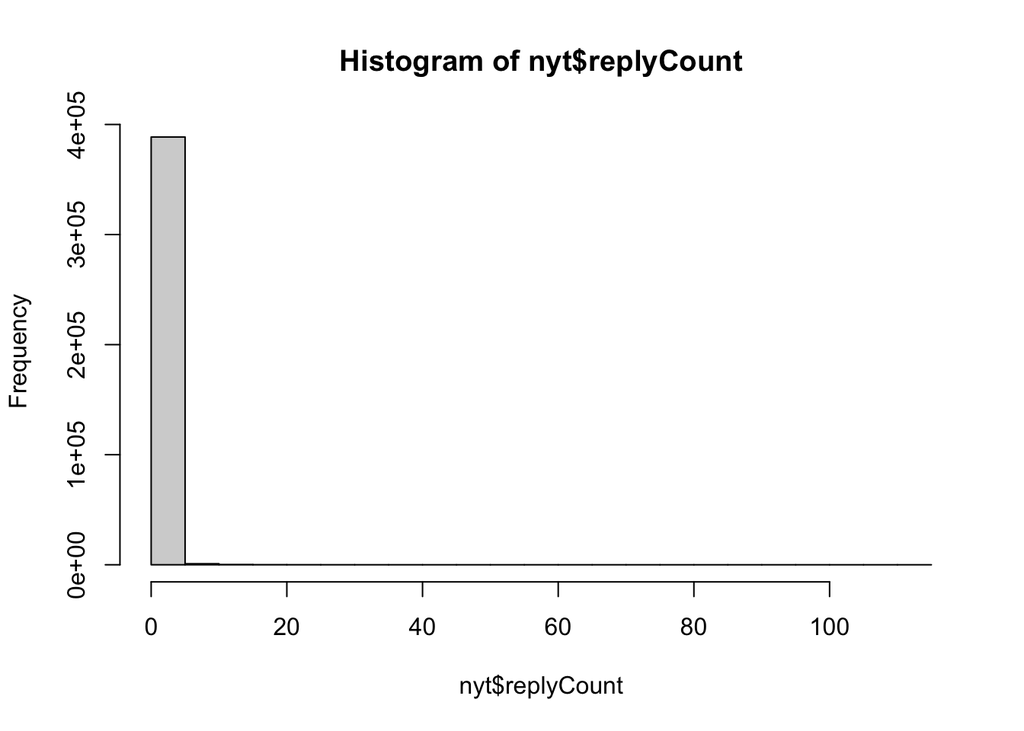

```r
hist(nyt$replyCount)
```

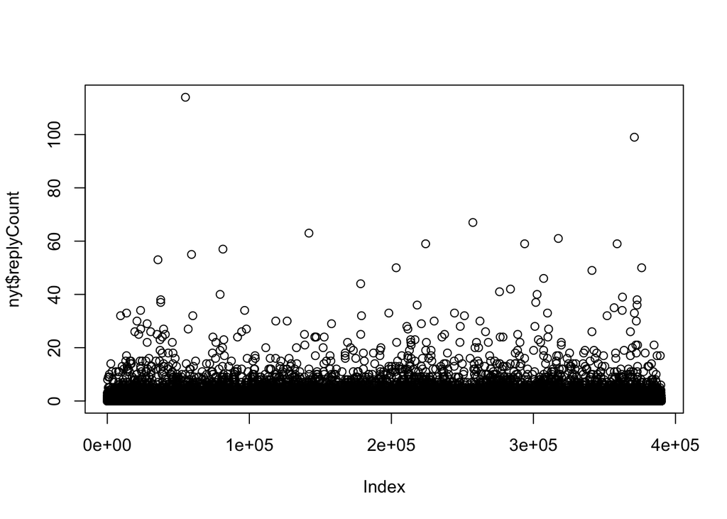

```r
plot(nyt$replyCount)
```

Checking our data for quality assurance could clearly become a lengthy process depending on the number of variables you’re looking at! Here are a few commands to make data exploration more concise:

NOTE: The datasummary_skim function output may appear empty in Markdown, but text is just white and can be seen if highlighted.

```r
#skim the entire dataframe using the skimr package
skim(nyt)
```

Data summary

| Name | nyt |
| --- | --- |
| Number of rows | 389963 |
| Number of columns | 29 |
| Key | NULL |
| _______________________ |  |
| Column type frequency: |  |
| character | 10 |
| logical | 5 |
| numeric | 14 |
| ________________________ |  |
| Group variables | None |

**Variable type: character**

| skim_variable | n_missing | complete_rate | min | max | empty | n_unique | whitespace |
| --- | --- | --- | --- | --- | --- | --- | --- |
| status | 0 | 1.00 | 8 | 8 | 0 | 1 | 0 |
| userDisplayName | 25 | 1.00 | 1 | 254 | 0 | 75693 | 0 |
| userLocation | 241963 | 0.38 | 2 | 25 | 0 | 214 | 0 |
| userTitle | 389954 | 0.00 | 6 | 46 | 0 | 7 | 0 |
| picURL | 383228 | 0.02 | 140 | 142 | 0 | 1734 | 0 |
| commentTitle | 0 | 1.00 | 7 | 7 | 0 | 1 | 0 |
| commentBody | 0 | 1.00 | 1 | 1566 | 0 | 387952 | 0 |
| replies | 0 | 1.00 | 2 | 3514 | 0 | 43390 | 0 |
| commentType | 0 | 1.00 | 7 | 13 | 0 | 2 | 0 |
| recipe_name | 0 | 1.00 | 1 | 85 | 0 | 8451 | 0 |

**Variable type: logical**

| skim_variable | n_missing | complete_rate | mean | count |
| --- | --- | --- | --- | --- |
| userURL | 389963 | 0 | NaN | : |
| editorsSelection | 0 | 1 | 0 | FAL: 389962, TRU: 1 |
| parentID | 389963 | 0 | NaN | : |
| parentUserDisplayName | 389963 | 0 | NaN | : |
| isAnonymous | 0 | 1 | 0 | FAL: 389956, TRU: 7 |

**Variable type: numeric**

| skim_variable | n_missing | complete_rate | mean | sd | p0 | p25 | p50 | p75 | p100 | hist |
| --- | --- | --- | --- | --- | --- | --- | --- | --- | --- | --- |
| V1 | 0 | 1 | 9.857000e+01 | 152.56 | 0 | 15 | 46 | 116 | 1705 | ▇▁▁▁▁ |
| commentID | 0 | 1 | 7.341614e+07 | 41466234.79 | 13918475 | 25791077 | 103490997 | 109167340 | 113390475 | ▆▁▁▁▇ |
| commentSequence | 0 | 1 | 7.341614e+07 | 41466234.79 | 13918475 | 25791077 | 103490997 | 109167340 | 113390475 | ▆▁▁▁▇ |
| userID | 0 | 1 | 6.157924e+07 | 27249884.48 | 0 | 48022158 | 65716760 | 77622272 | 168185963 | ▃▇▇▁▁ |
| createDate | 0 | 1 | 1.563805e+09 | 39753352.22 | 1506535652 | 1517507826 | 1572921711 | 1600379839 | 1624644283 | ▇▃▃▆▆ |
| updateDate | 0 | 1 | 1.583112e+09 | 29467403.04 | 1534873477 | 1553461799 | 1590170384 | 1609358704 | 1624647142 | ▆▂▃▆▇ |
| approveDate | 0 | 1 | 1.556066e+09 | 52665810.20 | 1422032767 | 1517503355 | 1572952389 | 1600383580 | 1624644311 | ▂▂▃▅▇ |
| recommendations | 0 | 1 | 5.040000e+00 | 30.33 | 0 | 0 | 0 | 1 | 3515 | ▇▁▁▁▁ |
| replyCount | 0 | 1 | 1.900000e-01 | 0.95 | 0 | 0 | 0 | 0 | 114 | ▇▁▁▁▁ |
| depth | 0 | 1 | 1.000000e+00 | 0.00 | 1 | 1 | 1 | 1 | 1 | ▁▁▇▁▁ |
| trusted | 0 | 1 | 0.000000e+00 | 0.00 | 0 | 0 | 0 | 0 | 0 | ▁▁▇▁▁ |
| recommendedFlag | 0 | 1 | 0.000000e+00 | 0.00 | 0 | 0 | 0 | 0 | 0 | ▁▁▇▁▁ |
| permID | 0 | 1 | 7.341614e+07 | 41466234.79 | 13918475 | 25791077 | 103490997 | 109167340 | 113390475 | ▆▁▁▁▇ |
| recipe_id | 0 | 1 | 9.641468e+05 | 227262.72 | 852 | 1016103 | 1018730 | 1020415 | 1022354 | ▁▁▁▁▇ |

```r
datasummary_skim(nyt,) # create table for R Markdown
```

Unique

Missing Pct.

Mean

SD

Min

Median

Max

Histogram

V1

1706

0

98.6

152.6

0.0

46.0

1705.0

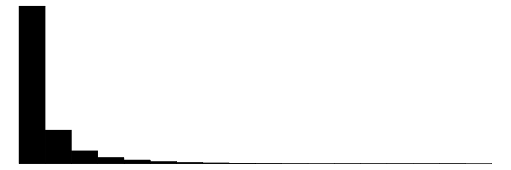

commentID

389738

0

73416138.1

41466234.8

13918475.0

103490997.0

113390475.0

commentSequence

389738

0

73416138.1

41466234.8

13918475.0

103490997.0

113390475.0

userID

154253

0

61579242.6

27249884.5

0.0

65716760.0

168185963.0

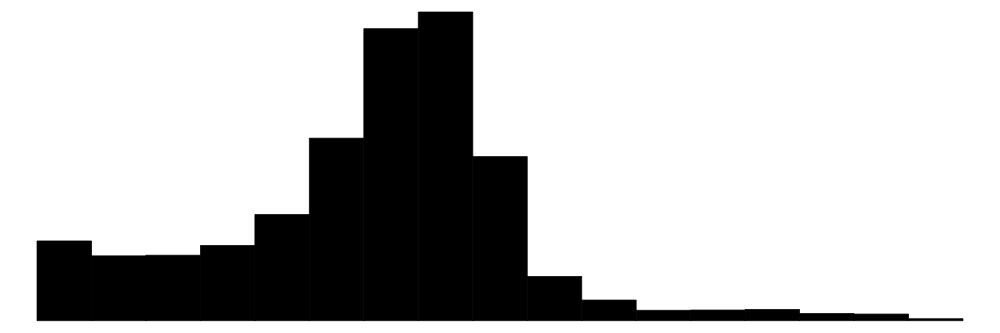

createDate

346960

0

1563804724.6

39753352.2

1506535652.0

1572921711.0

1624644283.0

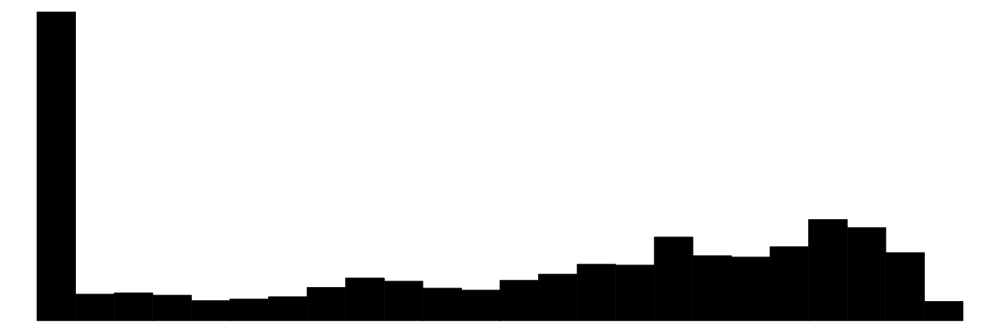

updateDate

193817

0

1583112469.5

29467403.0

1534873477.0

1590170384.0

1624647142.0

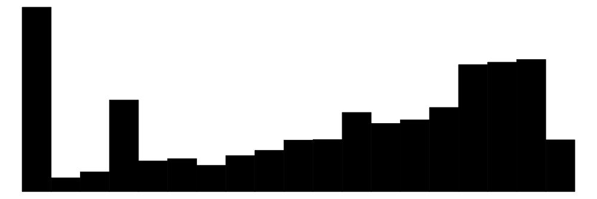

approveDate

122759

0

1556065791.6

52665810.2

1422032767.0

1572952389.0

1624644311.0

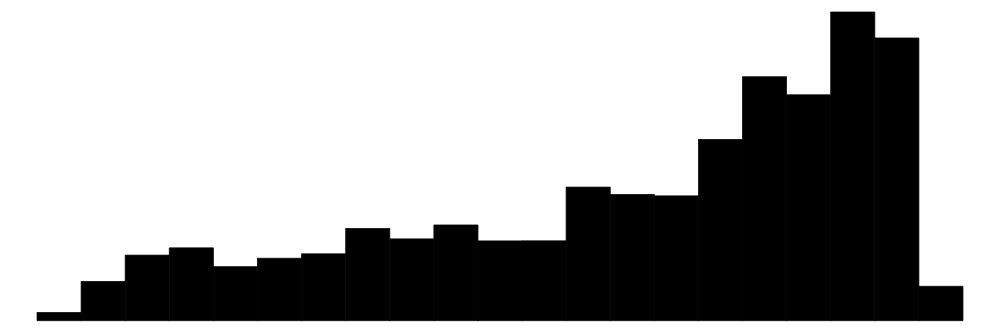

recommendations

642

0

5.0

30.3

0.0

0.0

3515.0

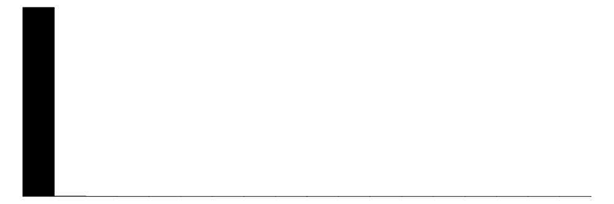

replyCount

55

0

0.2

1.0

0.0

0.0

114.0

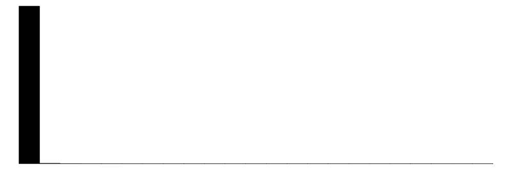

depth

1

0

1.0

0.0

1.0

1.0

1.0

trusted

1

0

0.0

0.0

0.0

0.0

0.0

recommendedFlag

1

0

0.0

0.0

0.0

0.0

0.0

permID

389738

0

73416138.1

41466234.8

13918475.0

103490997.0

113390475.0

recipe_id

8436

0

964146.8

227262.7

852.0

1018730.0

1022354.0

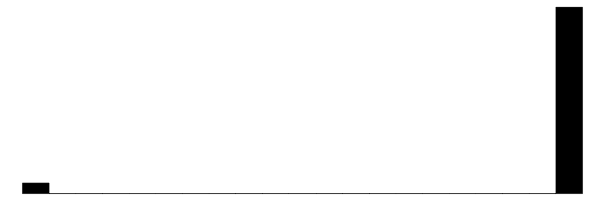

N

%

approved

389963

100.0

userTitle

Culture Reporter

3

0.0

Editor

1

0.0

National Correspondent

1

0.0

Production Associate, NYT Live

1

0.0

Reporter

1

0.0

Seattle Bureau Chief

1

0.0

Senior Correspondent and Editor, Gender Issues

1

0.0

NA

389954

100.0

<br\//>

389963

100.0

editorsSelection

FALSE

389962

100.0

TRUE

1

0.0

commentType

comment

389952

100.0

reporterReply

11

0.0

isAnonymous

FALSE

389956

100.0

TRUE

7

0.0

## Troubleshooting

To search a function

```r
#? [FUNCTION] # use this to learn more about a specific function - see help tab
?hist()
```

## Check your work

Use head() fun to check work at each step in the process

```r
head(nyt, n = 10) # specify number of rows desired
```

```
##        V1 commentID   status commentSequence   userID userDisplayName
##     <int>     <num>   <char>           <num>    <num>          <char>
##  1:     0  20158342 approved        20158342  1570140         Christa
##  2:     0 110917145 approved       110917145 87444971         Lindsey
##  3:     1 104240855 approved       104240855 68602151        VFR Marc
##  4:     0  16837960 approved        16837960 30298351          Joanne
##  5:     0 111016114 approved       111016114 57140404          Rachel
##  6:     1 109781447 approved       109781447 70214070  Kiran starosta
##  7:     2 109316251 approved       109316251 70214070  Kiran starosta
##  8:     3 108867570 approved       108867570 72725031   MameChristina
##  9:     4 108006364 approved       108006364 64690176   Blair Hoffman
## 10:     5 107941091 approved       107941091 57639707           Amber
##     userLocation userTitle userURL picURL commentTitle
##           <char>    <char>  <lgcl> <char>       <char>
##  1:        <br/>      <NA>      NA   <NA>     <br\\//>
```

[output cut: 69 more lines]

## Renaming columns

Raw data here is very messy - give columns more consistent and descriptive names using the rename() function from the dplyr package.

```r
names(nyt)
```

```
##  [1] "V1"                    "commentID"             "status"
##  [4] "commentSequence"       "userID"                "userDisplayName"
##  [7] "userLocation"          "userTitle"             "userURL"
## [10] "picURL"                "commentTitle"          "commentBody"
## [13] "createDate"            "updateDate"            "approveDate"
## [16] "recommendations"       "replyCount"            "replies"
## [19] "editorsSelection"      "parentID"              "parentUserDisplayName"
## [22] "depth"                 "commentType"           "trusted"
## [25] "recommendedFlag"       "permID"                "isAnonymous"
## [28] "recipe_id"             "recipe_name"
```

```r
# Rename individual columns using consistent naming conventions with rest of df
nyt <- dplyr::rename(nyt,
                     c('recipeName' = 'recipe_name',
                       'recipeID' = 'recipe_id'))

# Or rename columns in a batch!
nyt <- rename_with(nyt, ~ (gsub("user",
                                "author",
                                .x,
                                fixed = TRUE)))

#check work
head(nyt, n = 10)
```

```
##        V1 commentID   status commentSequence authorID authorDisplayName
##     <int>     <num>   <char>           <num>    <num>            <char>
##  1:     0  20158342 approved        20158342  1570140           Christa
##  2:     0 110917145 approved       110917145 87444971           Lindsey
##  3:     1 104240855 approved       104240855 68602151          VFR Marc
##  4:     0  16837960 approved        16837960 30298351            Joanne
##  5:     0 111016114 approved       111016114 57140404            Rachel
##  6:     1 109781447 approved       109781447 70214070    Kiran starosta
##  7:     2 109316251 approved       109316251 70214070    Kiran starosta
##  8:     3 108867570 approved       108867570 72725031     MameChristina
##  9:     4 108006364 approved       108006364 64690176     Blair Hoffman
## 10:     5 107941091 approved       107941091 57639707             Amber
##     authorLocation authorTitle authorURL picURL commentTitle
##             <char>      <char>    <lgcl> <char>       <char>
##  1:          <br/>        <NA>        NA   <NA>     <br\\//>
```

[output cut: 69 more lines]

## Selecting Columns and Filtering Rows

It looks like there are a lot of extra columns we aren’t interested in in this data. We can access the column names directly using the names function (above), and then use dplyr’s select() function to choose the columns we would like to keep. I usually specify that I want to use dplyr’s select() function instead of any select function from another package (for example, there’s also one in the psych package that sometimes conflicts with dplyr) by writing the package name and 2 colons before the function (dplyr::select()).

We can also clean data up to use only rows that we are interested in using filter() or subset() functions. I’m first going to select all rows with “approved” comments by using the filter() function. It’s worth noting that one can filter for rows containing values in a column that are equal to (==) or unequal to (!=) a specific reference value. You can do the same for numeric variables (as we’ll see later on in the “arrange and sort” section), or could also select reference values that are greater than (>)/greater than or equal to (>=), or less than (<)/less than or equal to (<=) a specific reference value.

```r
#select by row: this will allow us to keep only comments that have been "approved"
nyt <- filter(nyt, status == "approved") #find status = approved
nrow(nyt) #looks like we didn't lose any rows, so they all were "approved"!
```

```
## [1] 389963
```

```r
#select by column: this will allow us to choose only columns we'll need for the rest of our analyses
names(nyt)
```

```
##  [1] "V1"                    "commentID"             "status"
##  [4] "commentSequence"       "authorID"              "authorDisplayName"
##  [7] "authorLocation"        "authorTitle"           "authorURL"
## [10] "picURL"                "commentTitle"          "commentBody"
## [13] "createDate"            "updateDate"            "approveDate"
## [16] "recommendations"       "replyCount"            "replies"
## [19] "editorsSelection"      "parentID"              "parentUserDisplayName"
## [22] "depth"                 "commentType"           "trusted"
## [25] "recommendedFlag"       "permID"                "isAnonymous"
## [28] "recipeID"              "recipeName"
```

```r
nyt <- dplyr::select(nyt, c('commentID', 'commentBody', 'createDate',
                            'recommendations', 'recipeName', 'recipeID',
                            'replyCount', 'authorID', 'status'))

#remove an additional column
nyt <- dplyr::select(nyt, -c('status'))

#just for instructional purposes-- select columns with with certain titles using "matches" and "starts_with"
nyt_recipes <- dplyr::select(nyt, matches('recipe') | matches('comment'))
nyt_recipes <- dplyr::select(nyt, starts_with('recipe'))
nyt_IDs <- dplyr::select(nyt, ends_with('ID'))

#you can also use "select" to rearrange columns into a desired order:
nyt <- dplyr::select(nyt, c("recipeName", "recipeID"), everything())

head(nyt, n = 10)
```

```
##                                         recipeName recipeID commentID
##                                             <char>    <int>     <num>
##  1: shredded oxtail salad with mustard and shallot  1015646  20158342
##  2:                             aunt gens biscotti  1012940 110917145
##  3:                             aunt gens biscotti  1012940 104240855
##  4:                          turkey dinner canapes  1017810  16837960
##  5:                                lalla mussa dal  1019207 111016114
##  6:                                lalla mussa dal  1019207 109781447
##  7:                                lalla mussa dal  1019207 109316251
##  8:                                lalla mussa dal  1019207 108867570
##  9:                                lalla mussa dal  1019207 108006364
## 10:                                lalla mussa dal  1019207 107941091
##                                                                                                                                                                                                                                                                                                          …
##                                                                                                                                                                                                                                                                                                          …
##  1:                                                                                                                Not worth the effort--now I know why oxtails are on clearance every week. The meat was extremely fatty & difficult to debone. The article will tell you although the recipe does not t…
```

[output cut: 21 more lines]

## Using piping to make data wrangling more concise

Piping in R is possible through the magittr package, which itself is included in the tidyverse packages.

First save the raw data to a new dataframe called “nyt_concise”, and execute a more concise version of the steps taken above to reach the same result we have in our current “nyt” dataframe.

```r
nyt_concise <- nyt_raw

nyt_concise <- nyt_concise %>%
               filter(status == "approved") %>%
               dplyr::select(matches('recipe') |
                            matches('commentID') |
                            matches('commentBody') |
                            matches('recommendations') |
                            matches('createDate') |
                            matches('replyCount')) %>%
               dplyr::rename(c('recipeName' = 'recipe_name',
                               'recipeID' = 'recipe_id'))

head(nyt_concise)
```

```
##    recipeID                                     recipeName commentID
##       <int>                                         <char>     <num>
## 1:  1015646 shredded oxtail salad with mustard and shallot  20158342
## 2:  1012940                             aunt gens biscotti 110917145
## 3:  1012940                             aunt gens biscotti 104240855
## 4:  1017810                          turkey dinner canapes  16837960
## 5:  1019207                                lalla mussa dal 111016114
## 6:  1019207                                lalla mussa dal 109781447
##                                                                                                                                                                                                                                                                                                          …
##                                                                                                                                                                                                                                                                                                          …
## 1:                                             Not worth the effort--now I know why oxtails are on clearance every week. The meat was extremely fatty & difficult to debone. The article will tell you although the recipe does not that this is besr served on crisp winter greens such as frisee or wat…
## 2: This is the biscotti recipe I've been searching for! Anise biscotti at many Italian bakeries are more like Anise ""toast"" - super light, very crispy, and must be dunked to be enjoyed. These are dense and more cookie like, easily eaten on their own. They remind me of biscotti I would buy a dec…
## 3:                                                                                                                                                                                                                                                                                     These biscotti are…
## 4:                                                                                                                                                                                                                                                                                                       …
## 5:                                                                                                                  This is very good, but please note that it's tomato puree, not tomato paste. I used the latter based on an initial misread and then the quantity matched the volume of a can, so I we…
## 6:                                                                                                                                                                                                                                                                                                       …
##    recommendations createDate replyCount
##              <num>      <num>      <num>
## 1:               1 1508886192          0
## 2:               0 1609889919          0
## 3:               1 1576802688          0
## 4:               1 1509378566          0
## 5:               0 1610300709          0
## 6:               0 1603568760          0
```

## Arrange

Let’s say we wanted to have sort our data by date of the original comment. The comments come in unix date-time format, and we can use the as_datetime() function from the lubridate package to put the date into a readable format To arrange by date, we’ll use the arrange() function from dplyr, which arranges values in ascending order by default and can be reversed by adding the `desc() argument.

```r
#replace UNIX timestamps with interpretable date/time
nyt$createDate <- as_datetime(nyt$createDate)

#arrange by date (in ascending order by default: earliest dates first)
nyt <- arrange(nyt, createDate)

#arrange by date in descending order: latest dates first
nyt <- arrange(nyt, desc(createDate))

#select only reviews from 2021
nyt <- filter(nyt, createDate >= '2021-01-01 00:00:00') #greater than or equal to operator
nrow(nyt) #down from 389,963 to 53,355 reviews after cutting out all before 2021
```

```
## [1] 53355
```

```r
head(nyt, n = 10)
```

```
##                                                   recipeName recipeID commentID
##                                                       <char>    <int>     <num>
##  1: joojeh kabab ba holu saffron chicken kababs with peaches  1022310 113390475
##  2:                            sesame snap pea chicken salad  1022301 113390368
##  3:                                    tuna salad sandwiches  1022354 113390226
##  4:                                    tuna salad sandwiches  1022354 113390169
##  5:                                         hot sauce shrimp  1022328 113390071
##  6:                                         hot sauce shrimp  1022328 113389929
##  7:                                    tuna salad sandwiches  1022354 113389669
##  8:                                    tuna salad sandwiches  1022354 113389668
##  9:                                    tzatziki potato salad  1022307 113389645
## 10:                                    tuna salad sandwiches  1022354 113389613
##                                                                                                                                                                                                                                                                                                          …
##                                                                                                                                                                                                                                                                                                          …
##  1:                                                                                                                                                                                                                      I'd recommend pureeing the onion and adding it to the marinade instead. I've had…
```

[output cut: 21 more lines]

How would we add the arrange(), and filter() functions above into our “nyt_concise” dataframe?

```r
#changing the creation date to timedate format must be done separately
nyt_concise$createDate <-lubridate::as_datetime(nyt_concise$createDate)

nyt_concise <- nyt_concise %>%
  arrange(createDate) %>%
  filter(createDate >= '2021-01-01 00:00:00')

head(nyt_concise)
```

```
##    recipeID                                    recipeName commentID
##       <int>                                        <char>     <num>
## 1:  1020738                          mushroom bourguignon 110843867
## 2:  1021767 mulling spice cake with cream cheese frosting 110843870
## 3:  1021590                               red lentil loaf 110843895
## 4:  1020258      no bake lemon custards with strawberries 110843932
## 5:  1020640                               beef wellington 110843951
## 6:  1020738                          mushroom bourguignon 110843954
##                                                                                                                                                                                                                                                                           commentBody
##                                                                                                                                                                                                                                                                                <char>
## 1:                                                                                                        We had this for NYE and it was scrumptious! Didn't have pearl onions; used kinda regular mushrooms - didn't matter! Lovely over polenta. Mmmm. I'll be making this again...
## 2:                                                                   This recipe came out quite thick, not runny.  The cakes are quite dense.  I wondered if my molasses was too thick or if I should have doubled the cider.  Something seems off in the moisture content as written
## 3: I enjoyed this! As others have noted it tends to be a bit dry, so I added a tbsp. of olive oil to the food processor. The leftovers will make an encore in a lunchtime grain bowl. The yogurt sauce is essential.\n\nGlad I used an 8x4 loaf pan. A 9x5 would have been too large.
## 4:                                                                                                                                                                                                                                       Really good — next time I’ll use less sugar.
## 5:                                                                                                                                    Easier than I expected and fabulous results. I used a food processor to chop the mushrooms, but next time I’ll hand chop them for more texture.
## 6:                                                    Delicious and practically perfect as written. I did add another tablespoon of tamari. Served over polenta with a side of broccoli rabe. The rabe's sharpness was a great contrast to the comforting, rich flavors of this dish.
##    recommendations          createDate replyCount
##              <num>              <POSc>      <num>
## 1:               0 2021-01-01 05:11:22          0
## 2:               0 2021-01-01 05:12:09          2
## 3:               1 2021-01-01 05:19:06          0
## 4:               0 2021-01-01 05:23:51          0
## 5:               1 2021-01-01 05:27:25          0
## 6:               0 2021-01-01 05:28:00          0
```

#Mutating data, merging dataframes, exporting data

## Mutate and Transmute: create columns based on existing columns

To create new columns based on the content of other columns in a dataframe, we can use the mutate() function from the dplyr package. Using the transmute() function will achieve the same results as mutate() and is written the same way, but while mutate() will retain both the original and newly-created columns, transmute() keeps only the newly-created column. Here, we’ll create a new column containing the number of words in each comment called “textLength” and will keep the reference column (“commentBody”) by using mutate().

```r
### Create New Columns ###
#create a new column based on other columns
nyt <- mutate(nyt, textLength = qdap::word_count(nyt$commentBody)) #text length column

head(nyt, n = 10)
```

```
##                                                   recipeName recipeID commentID
##                                                       <char>    <int>     <num>
##  1: joojeh kabab ba holu saffron chicken kababs with peaches  1022310 113390475
##  2:                            sesame snap pea chicken salad  1022301 113390368
##  3:                                    tuna salad sandwiches  1022354 113390226
##  4:                                    tuna salad sandwiches  1022354 113390169
##  5:                                         hot sauce shrimp  1022328 113390071
##  6:                                         hot sauce shrimp  1022328 113389929
##  7:                                    tuna salad sandwiches  1022354 113389669
##  8:                                    tuna salad sandwiches  1022354 113389668
##  9:                                    tzatziki potato salad  1022307 113389645
## 10:                                    tuna salad sandwiches  1022354 113389613
##                                                                                                                                                                                                                                                                                                          …
##                                                                                                                                                                                                                                                                                                          …
##  1:                                                                                                                                                                                                                      I'd recommend pureeing the onion and adding it to the marinade instead. I've had…
```

[output cut: 21 more lines]

## Miscellaneous text cleaning

```r
#remove unwanted characters
nyt$commentBody <- str_trim(gsub("\n\n", "", nyt$commentBody))
nyt$commentBody <- str_trim(gsub("\n", "", nyt$commentBody))

#tokenize
nyt_text <- dplyr::select(nyt, c('commentBody', 'commentID'))
nyt_text <- nyt_text %>% unnest_tokens(word, commentBody) %>% #create tokens for each word
  anti_join(stop_words) #remove stop words using SMART lexicon
nyt_text <- nyt_text %>% group_by(commentID) %>% summarise(commentBody = paste0(word, collapse = ' ')) #collapse back into original reviews

#get sentiment scores for each comment
nyt_text$sentiment <- get_sentiment(nyt_text$commentBody, method = "afinn")
head(nyt_text)
```

```
## # A tibble: 6 × 3
##   commentID commentBody                                                sentiment
##       <dbl> <chr>                                                          <int>
## 1 110843867 nye scrumptious pearl onions kinda regular mushrooms matt…         4
## 2 110843870 recipe thick runny cakes dense wondered molasses thick do…         0
## 3 110843895 enjoyed noted bit dry added tbsp olive oil food processor…         5
## 4 110843932 time i’ll sugar                                                    0
## 5 110843951 easier expected fabulous results food processor chop mush…         4
## 6 110843954 delicious practically perfect written add tablespoon tama…        10
```

```r
#standardize sentiment scores
nyt_text$sentiment <- scale(nyt_text$sentiment, center=T, scale=T)

#rename tokenized comment body
nyt_text <- rename(nyt_text, c('commentToken' = 'commentBody'))

head(nyt_text)
```

```
## # A tibble: 6 × 3
##   commentID commentToken                                           sentiment[,1]
##       <dbl> <chr>                                                          <dbl>
## 1 110843867 nye scrumptious pearl onions kinda regular mushrooms …         0.378
## 2 110843870 recipe thick runny cakes dense wondered molasses thic…        -0.798
## 3 110843895 enjoyed noted bit dry added tbsp olive oil food proce…         0.672
## 4 110843932 time i’ll sugar                                               -0.798
## 5 110843951 easier expected fabulous results food processor chop …         0.378
## 6 110843954 delicious practically perfect written add tablespoon …         2.14
```

# Join dataframes

Lastly, we will walk through dplyr’s functions for merging two dataframes together. We’ll use left_join() so that all of the columns from our newly-cleaned nyt_text dataframe can be matched with columns in our cleaned nyt dataframe. There are several different ways this could be achieved using dplyr’s join functions: left_join() (appends all rows in df y that match those in df x to df x), right_join() (appends all rows in df x that match df y to df y), inner_join() (appends all rows that match in df x and df y), and full_join() (appends all rows in df x and df y regardless of row match). These can each be helpful depending on the data structure you’re hoping to achieve.

```r
#left_join to merge nyt and nyt_text dataframes
nyt <- left_join(nyt, nyt_text, by=c('commentID'))

head(nyt, n = 20)
```

```
##                                                   recipeName recipeID commentID
##                                                       <char>    <int>     <num>
##  1: joojeh kabab ba holu saffron chicken kababs with peaches  1022310 113390475
##  2:                            sesame snap pea chicken salad  1022301 113390368
##  3:                                    tuna salad sandwiches  1022354 113390226
##  4:                                    tuna salad sandwiches  1022354 113390169
##  5:                                         hot sauce shrimp  1022328 113390071
##  6:                                         hot sauce shrimp  1022328 113389929
##  7:                                    tuna salad sandwiches  1022354 113389669
##  8:                                    tuna salad sandwiches  1022354 113389668
##  9:                                    tzatziki potato salad  1022307 113389645
## 10:                                    tuna salad sandwiches  1022354 113389613
## 11:                       vegetable tabbouleh with chickpeas  1022259 113389482
## 12:                       vegetable tabbouleh with chickpeas  1022259 113389412
## 13:                                    tuna salad sandwiches  1022354 113389384
```

[output cut: 100 more lines]

## Saving your cleaned data

Especially for large datasets like this one, it can be costly for your computer’s memory (and your time!) to rerun all of the cleaning steps above. By writing the cleaned data into a new csv file, you can load in your successfully wrangled data the next time you want to use it for analyses or visualizations.

```r
#if you don't want to rerun data cleaning steps, you can save and read in cleaned data directly
write.csv(nyt, "nyt_clean.csv") #this will save the cleaned file from above into a csv called "nyt_clean" in your working directory folder
```

# Application

## Exercise 2

For the second exercise, I’m going to ask you to use the functions above to answer a few specific questions about our final cleaned “nyt” dataset that might be similar to some exploratory steps you’d take on your own data.

## How many rows and columns are in the dataset?

```r
## How many rows and columns are in the dataset?
skim(nyt)
```

Data summary

| Name | nyt |
| --- | --- |
| Number of rows | 53355 |
| Number of columns | 11 |
| Key | NULL |
| _______________________ |  |
| Column type frequency: |  |
| character | 3 |
| numeric | 7 |
| POSIXct | 1 |
| ________________________ |  |
| Group variables | None |

**Variable type: character**

| skim_variable | n_missing | complete_rate | min | max | empty | n_unique | whitespace |
| --- | --- | --- | --- | --- | --- | --- | --- |
| recipeName | 0 | 1 | 1 | 81 | 0 | 5353 | 0 |
| commentBody | 0 | 1 | 3 | 794 | 0 | 53201 | 0 |
| commentToken | 60 | 1 | 1 | 667 | 0 | 52724 | 0 |

**Variable type: numeric**

| skim_variable | n_missing | complete_rate | mean | sd | p0 | p25 | p50 | p75 | p100 | hist |
| --- | --- | --- | --- | --- | --- | --- | --- | --- | --- | --- |
| recipeID | 0 | 1 | 990590.46 | 168992.98 | 1466.00 | 1018509.0 | 1020617.00 | 1021775.00 | 1022354.00 | ▁▁▁▁▇ |
| commentID | 0 | 1 | 111840857.34 | 608141.97 | 110843867.00 | 111347040.5 | 111787897.00 | 112288809.50 | 113390475.00 | ▇▇▇▅▁ |
| recommendations | 0 | 1 | 1.51 | 13.49 | 0.00 | 0.0 | 0.00 | 0.00 | 1270.00 | ▇▁▁▁▁ |
| replyCount | 0 | 1 | 0.06 | 0.32 | 0.00 | 0.0 | 0.00 | 0.00 | 8.00 | ▇▁▁▁▁ |
| authorID | 0 | 1 | 71060701.55 | 32848774.53 | 3513.00 | 55046908.0 | 70472317.00 | 84002334.00 | 168185963.00 | ▂▆▇▁▁ |
| textLength | 0 | 1 | 40.75 | 25.17 | 1.00 | 20.0 | 36.00 | 59.00 | 108.00 | ▇▇▆▃▂ |
| sentiment | 60 | 1 | 0.00 | 1.00 | -4.91 | -0.8 | -0.21 | 0.67 | 7.14 | ▁▇▇▁▁ |

**Variable type: POSIXct**

| skim_variable | n_missing | complete_rate | min | max | median | n_unique |
| --- | --- | --- | --- | --- | --- | --- |
| createDate | 0 | 1 | 2021-01-01 05:11:22 | 2021-06-25 18:04:43 | 2021-02-28 13:19:06 | 53136 |

```r
# 53355 rows
# 11 columns
```

```r
## What classes are the "commentBody" and "textLength" columns?
str(nyt)
```

```
## Classes 'data.table' and 'data.frame':   53355 obs. of  11 variables:
##  $ recipeName     : chr  "joojeh kabab ba holu saffron chicken kababs with peaches" "sesame snap pea chicken salad" "tuna salad sandwiches" "tuna salad sandwiches" ...
##  $ recipeID       : int  1022310 1022301 1022354 1022354 1022328 1022328 1022354 1022354 1022307 1022354 ...
##  $ commentID      : num  1.13e+08 1.13e+08 1.13e+08 1.13e+08 1.13e+08 ...
##  $ commentBody    : chr  "I'd recommend pureeing the onion and adding it to the marinade instead. I've had this dish many, many times and"| __truncated__ "serve over brown rice.." "Add a cubed Apple and you have something outrageous" "Potato chips work superbly on a ham sandwich too!" ...
##  $ createDate     : POSIXct, format: "2021-06-25 18:04:43" "2021-06-25 17:56:00" ...
##  $ recommendations: num  0 0 0 0 0 12 0 1 0 0 ...
##  $ replyCount     : num  0 0 0 0 2 0 0 0 0 0 ...
##  $ authorID       : num  8.61e+07 2.54e+07 1.23e+08 6.35e+07 5.89e+07 ...
##  $ textLength     : int  27 4 9 9 14 50 29 22 62 28 ...
##  $ commentToken   : chr  "recommend pureeing onion adding marinade dish times nuanced" "serve brown rice" "add cubed apple outrageous" "potato chips superbly ham sandwich" ...
##  $ sentiment      : num [1:53355, 1] -0.21 -0.798 -1.68 -0.798 -0.798 ...
##   ..- attr(*, "scaled:center")= num 2.72
##   ..- attr(*, "scaled:scale")= num 3.4
##  - attr(*, ".internal.selfref")=<externalptr>
```

```r
# commentBody = character variable
# textLength columns = interval variable
```

```r
## Turn textLength into a numeric variable (suggestion: use as.numeric()).
nyt$textLength <- as.numeric(nyt$textLength)

str(nyt$textLength)
```

```
##  num [1:53355] 27 4 9 9 14 50 29 22 62 28 ...
```

```r
## Use the skim() function to find the mean, SD, min and max for textLength, sentiment (Hint: we standardized sentiment earlier on, so M should be 0 and SD should be 1), and replyCount.

skim(nyt)
```

Data summary

| Name | nyt |
| --- | --- |
| Number of rows | 53355 |
| Number of columns | 11 |
| Key | NULL |
| _______________________ |  |
| Column type frequency: |  |
| character | 3 |
| numeric | 7 |
| POSIXct | 1 |
| ________________________ |  |
| Group variables | None |

**Variable type: character**

| skim_variable | n_missing | complete_rate | min | max | empty | n_unique | whitespace |
| --- | --- | --- | --- | --- | --- | --- | --- |
| recipeName | 0 | 1 | 1 | 81 | 0 | 5353 | 0 |
| commentBody | 0 | 1 | 3 | 794 | 0 | 53201 | 0 |
| commentToken | 60 | 1 | 1 | 667 | 0 | 52724 | 0 |

**Variable type: numeric**

| skim_variable | n_missing | complete_rate | mean | sd | p0 | p25 | p50 | p75 | p100 | hist |
| --- | --- | --- | --- | --- | --- | --- | --- | --- | --- | --- |
| recipeID | 0 | 1 | 990590.46 | 168992.98 | 1466.00 | 1018509.0 | 1020617.00 | 1021775.00 | 1022354.00 | ▁▁▁▁▇ |
| commentID | 0 | 1 | 111840857.34 | 608141.97 | 110843867.00 | 111347040.5 | 111787897.00 | 112288809.50 | 113390475.00 | ▇▇▇▅▁ |
| recommendations | 0 | 1 | 1.51 | 13.49 | 0.00 | 0.0 | 0.00 | 0.00 | 1270.00 | ▇▁▁▁▁ |
| replyCount | 0 | 1 | 0.06 | 0.32 | 0.00 | 0.0 | 0.00 | 0.00 | 8.00 | ▇▁▁▁▁ |
| authorID | 0 | 1 | 71060701.55 | 32848774.53 | 3513.00 | 55046908.0 | 70472317.00 | 84002334.00 | 168185963.00 | ▂▆▇▁▁ |
| textLength | 0 | 1 | 40.75 | 25.17 | 1.00 | 20.0 | 36.00 | 59.00 | 108.00 | ▇▇▆▃▂ |
| sentiment | 60 | 1 | 0.00 | 1.00 | -4.91 | -0.8 | -0.21 | 0.67 | 7.14 | ▁▇▇▁▁ |

**Variable type: POSIXct**

| skim_variable | n_missing | complete_rate | min | max | median | n_unique |
| --- | --- | --- | --- | --- | --- | --- |
| createDate | 0 | 1 | 2021-01-01 05:11:22 | 2021-06-25 18:04:43 | 2021-02-28 13:19:06 | 53136 |

```r
## Remove rows containing outliers for textLength, sentiment, and replyCount (greater or less than 3SD from the mean)
nyt <- subset(nyt, textLength <= 116.23)
nyt <- subset(nyt, sentiment <= 3 & sentiment >= -3)
nyt <- subset(nyt, replyCount <= 1.58)
```

```r
## Remove any rows with missing data. (Hint: use drop_na())
nyt <- drop_na(nyt)
nrow(nyt) #52189 rows remaining
```

```
## [1] 52189
```

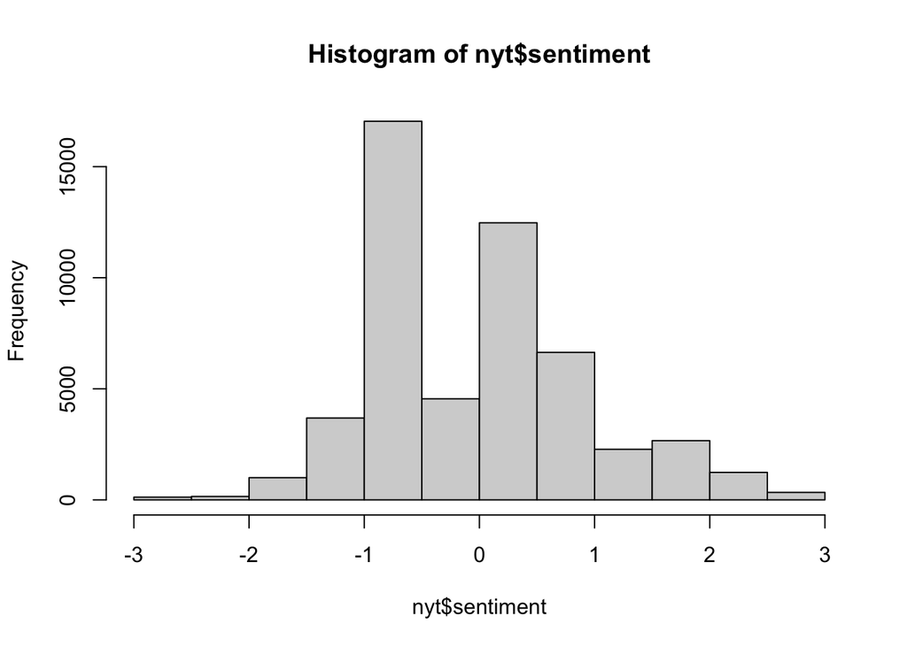

```r
## Plot histograms of the sentiment, textLength, and replyCount columns.
hist(nyt$sentiment)
```

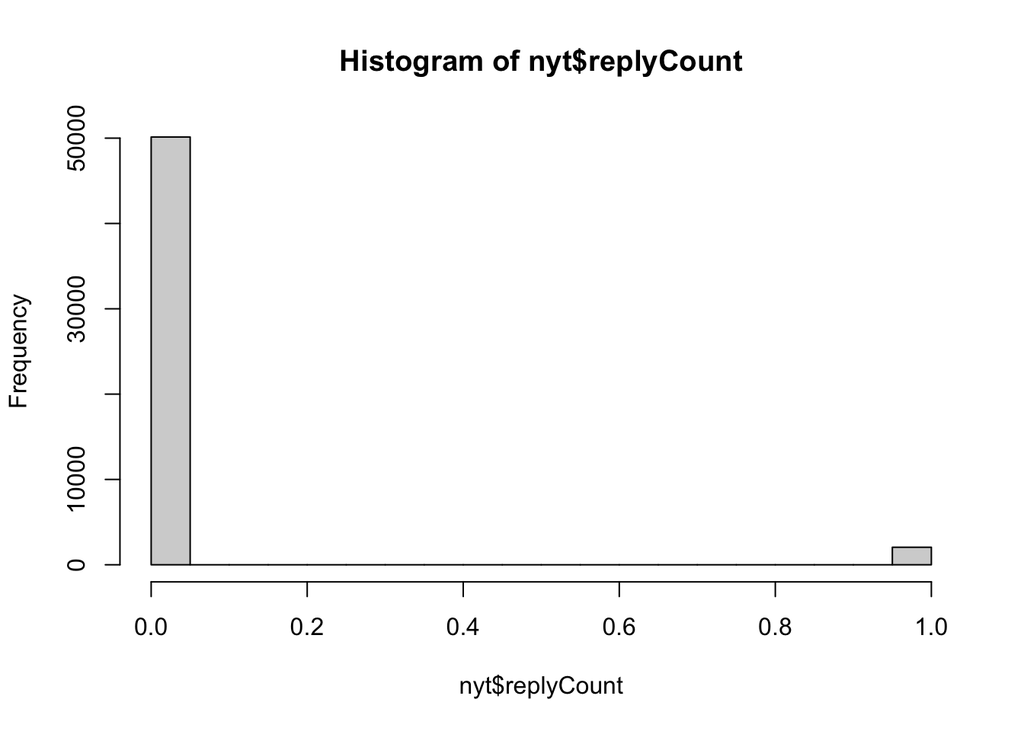

```r
hist(nyt$replyCount)
```

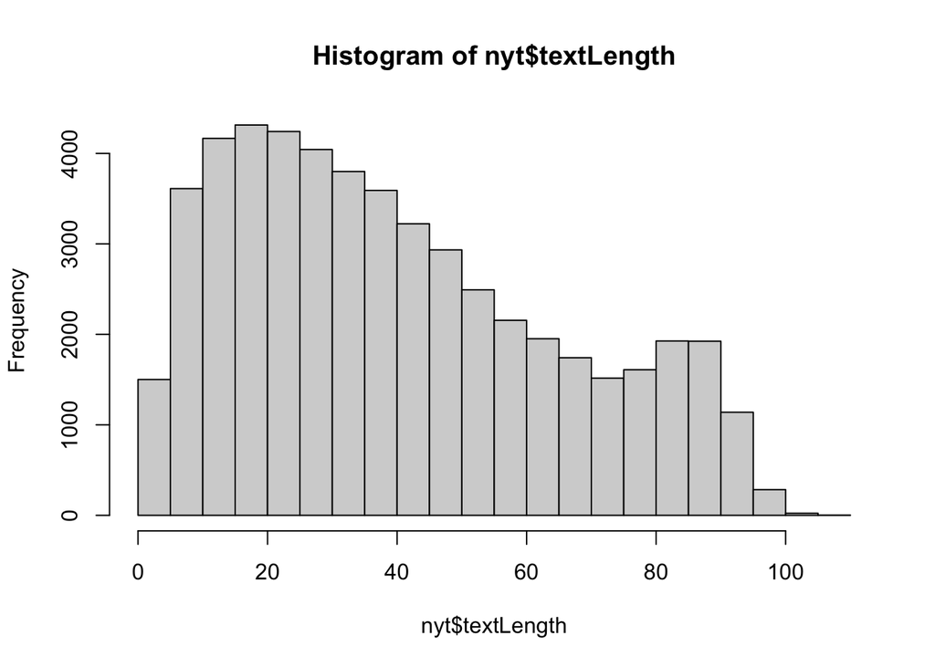

```r
hist(nyt$textLength)
```

```r
## Using the select() function and datasummary_correlation() function from the modelsummary package, create an intercorrelation table of all numeric variables aside from date and ID variables.

names(nyt)
```

```
##  [1] "recipeName"      "recipeID"        "commentID"       "commentBody"
##  [5] "createDate"      "recommendations" "replyCount"      "authorID"
##  [9] "textLength"      "commentToken"    "sentiment"
```

```r
nyt_cor <- dplyr::select(nyt, c('recommendations', 'textLength', 'replyCount','sentiment'))
datasummary_correlation(nyt_cor)
```

|  | recommendations | textLength | replyCount | sentiment |
| --- | --- | --- | --- | --- |
| recommendations | 1 | . | . | . |
| textLength | .03 | 1 | . | . |
| replyCount | .07 | -.04 | 1 | . |
| sentiment | -.02 | .26 | -.10 | 1 |

## Wrangling Data for Specific Analyses

Using a t-test via the t.test() function, compare comment sentiment for 2 different recipes. First, wrangle data into a usable format, and then perform the t-test.

```r
## Save nyt as new dataframe
nyt_analysis <- nyt
```

```r
### Concise ###
nyt_analysis <- nyt_analysis %>% dplyr::select(c('recipeName', 'sentiment', 'commentID')) %>% ## Select needed columns
  subset(recipeName == 'grilled tofu' | recipeName == 'crab rangoon') %>% ## Use subset() or filter() to select rows for 2 recipe names
  pivot_wider(id_cols = 'commentID', names_from = 'recipeName', values_from = 'sentiment') ## Use pivot_wider() (new function!) to transform data from long to wide format
```

```r
head(nyt_analysis, n = 20)
```

```
## # A tibble: 20 × 3
##    commentID `crab rangoon` `grilled tofu`
##        <dbl>          <dbl>          <dbl>
##  1 113382913         -0.210         NA
##  2 113378690         NA              0.965
##  3 113369706         -0.798         NA
##  4 113364702         -1.39          NA
##  5 113359773         -0.798         NA
##  6 113359161         -0.504         NA
##  7 113358960         -0.798         NA
##  8 113358830         -0.798         NA
##  9 113358720          1.26          NA
## 10 113358350         -0.798         NA
## 11 113329680         NA             -0.798
## 12 113327181         NA              1.26
## 13 113324043         NA             -0.504
## 14 113323209         NA             -0.798
## 15 113319291         NA             -0.210
## 16 113317364         NA              0.378
## 17 113316107         NA             -0.798
## 18 113314547         NA              2.73
## 19 113314449         NA             -0.210
## 20 113312430         NA             -0.798
```

## Use t.test to compare sentiment for recipe 1 with recipe 2

```r
t.test(nyt_analysis$`grilled tofu`, nyt_analysis$`crab rangoon`,
       alternative = c('two.sided'),
       paired = F,
       conf.level = .95)
```

```
##
##  Welch Two Sample t-test
##
## data:  nyt_analysis$`grilled tofu` and nyt_analysis$`crab rangoon`
## t = 0.63098, df = 13.849, p-value = 0.5383
## alternative hypothesis: true difference in means is not equal to 0
## 95 percent confidence interval:
##  -0.4315691  0.7908166
## sample estimates:
##  mean of x  mean of y
## -0.3572405 -0.5368642
```

Sentiment does not differ between grilled tofu and crab rangoon

## Linear Regressions

Using two simple linear regressions via the lm() function, examine a) whether replyCount is predicted by sentiment, and b) whether textLength predicts sentiment.

First, wrangle data into a usable format, and then perform the regressions. Feel free to use the help command in R (“?FUNCTION()) or the cheatsheets for any help. I’ve included suggested steps, but feel free to do whatever makes most sense to you .

```r
## Save nyt as new dataframe
nyt_reg <- nyt
```

### Select needed columns

```r
# view column names
names(nyt_reg)
```

```
##  [1] "recipeName"      "recipeID"        "commentID"       "commentBody"
##  [5] "createDate"      "recommendations" "replyCount"      "authorID"
##  [9] "textLength"      "commentToken"    "sentiment"
```

```r
nyt_reg <- dplyr::select(nyt_reg, c('commentID', 'replyCount', 'textLength', 'sentiment'))
head(nyt_reg)
```

```
##    commentID replyCount textLength  sentiment
##        <num>      <num>      <num>      <num>
## 1: 113390475          0         27 -0.2102756
## 2: 113390368          0          4 -0.7981352
## 3: 113390226          0          9 -1.6799247
## 4: 113390169          0          9 -0.7981352
## 5: 113389929          0         50 -0.2102756
## 6: 113389669          0         29 -0.2102756
```

## Standardize replyCount and textLength

```r
nyt_reg$replyCount <- scale(nyt_reg$replyCount, center = T, scale = T)
nyt_reg$textLength <- scale(nyt_reg$textLength, center = T, scale = T)
```